# QTM 151 - Introduction to Statistical Computing II

Lecture 05 - Boolean Logic and Conditional Statements

Danilo Freire

danilo.freire@emory.edu

Emory University

17 September, 2024

# Nice to see you all again! 😊

# Brief recap of last class 📚

## Brief recap

### In the last class, we did the following:

- Introduced Matplotlib and NumPy libraries and loaded them with `import matplotlib.pyplot as plt` and `import numpy as np`
- Created histograms and scatter plots with `plt.hist()` and `plt.scatter()`
- Explored NumPy mathematical functions: `np.log()`, `np.exp()`, `np.sin()`, `np.sqrt()`
- Created NumPy arrays and performed operations
  - Example: `np.array([1,2,3])`, `array1 + array2`
- Accessed array elements using indexing (e.g., `array[1:3]`)
- Performed scalar operations on arrays, such as `array * 2` or `array + 5`
- Computed summary statistics with `np.mean()`, `np.std()`, `np.min()`, `np.max()`
- Discussed importance of random numbers in simulations
- Generated random numbers: e.g., `np.random.normal(loc=0, scale=1, size=10)`
- Plotted histograms of random variables with `plt.hist()`

# Are you more comfortable with Python now? 🐍

# Today’s class 📚

## Today’s class

Today we will:

- Learn about [Boolean logic](https://en.wikipedia.org/wiki/Boolean_data_type)
- Discuss the importance of conditional statements in programming
- Understand how to use [conditional statements in Python](https://www.w3schools.com/python/python_conditions.asp)
- Explore the `if`, `elif`, and `else` statements
- Practice writing conditional statements in Python

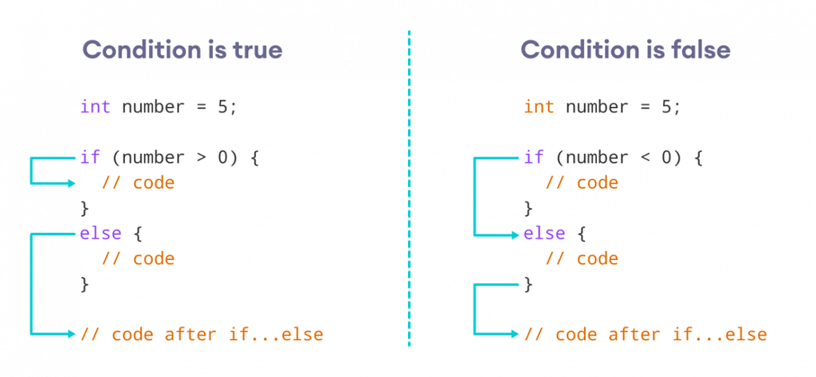

Let’s get started! 🚀

# Boolean logic 🧠

## Boolean logic

### A bit of history

- Named after [George Boole](https://en.wikipedia.org/wiki/George_Boole), a British mathematician and philosopher
- [Boole’s work on logic](https://en.wikipedia.org/wiki/Boolean_algebra) laid the foundation for modern computer science
- Boolean logic is a branch of algebra that deals with [true and false values](https://en.wikipedia.org/wiki/Boolean_data_type)
- It is useful for computer programming because it is based on [binary](https://en.wikipedia.org/wiki/Binary_number) values
- In Python, Boolean values are `True` and `False`
- We use them to make decisions in our code

[figure not shown]

# Testing expressions with text 🐍

## True and False values

- We can test whether two values are equal using the `==` operator (two equal signs)
- For example, `5 == 5` returns `True`
- We can also test whether two values are not equal using the `!=` operator (exclamation mark followed by an equal sign)
- Let’s see how this works in Python
- First, let’s load the `matplotlib` and `numpy` libraries

```python
import matplotlib.pyplot as plt
import numpy as np

# You can compare two strings by using a double "equal sign"
# This can be useful if you're trying to evaluate whether data was entered correctly

"Is this the real life?" == "is this just fantasy?"
```

```
False
```

Note: the order of the strings matter!

```python
"ab" == "ba"
```

```
False
```

## True and False values

- Equality of strings is most useful when you’re comparing an unknown variable to a benchmark
- Below, try switching the value of `any_questions`

```python
any_questions = "no"
print(any_questions == "no")
```

```
True
```

```python
any_questions = "yes"
print(any_questions == "no")
```

```
False
```

## Test for the presence of keywords in a sentence (`in` operator)

- We can test whether a keyword is present in a sentence or a list using the `in` operator
- For example, `"apple" in "I like apples"` returns `True`
- Let’s see how this works in Python

```python
"apple" in "I like apples"
```

```
True
```

```python
keyword = "economic"
sentence = "The Federal Reserve makes forecasts about many economic outcomes"

keyword in sentence

# Try changing the keyword!
```

```
True
```

- Now, let’s test whether a keyword is present in a list

```python
current_month = "September"
list_summer_months = ["June","July","August"]

print(current_month in list_summer_months)
print('June' in list_summer_months)
```

```
False
True
```

## Common pitfall when testing expressions

- Be careful when testing expressions with text
- Python is case-sensitive, so `"apple" == "Apple"` returns `False`
- To avoid this, you can use the `lower()` method to convert all characters to lowercase
- And please remember there is a difference between double equal signs `==` and single equal sign `=`

```python
"apple" == "Apple"
```

```
False
```

```python
"apple".lower() == "Apple".lower()
```

```
True
```

```python
# A single vs double equality sign makes a BIG difference
# When you have a single equality (=) you are assignning the variable
# When you have a double equality (==) you are comparing two values
message_hello = "hello"

print(message_hello == "hello")
```

```
True
```

## Try it out!

- Now, let’s test whether you can identify the correct expression
- Write code to check whether the string “red” is contained in the list: `["red","green","yellow","orange"]` Appendix 01

# So far so good? 🤔

# Testing expressions with numbers 🐍

## Testing expressions with numbers

- Tests with numbers
  - Strictly less than (<), less than or equal (<=)
  - Equal (==)
  - Strictly more than (>), greater than or equal to (>=)
- Let’s see how this works in Python

```python
x = 5

print(x < 5)
print(x <= 5)
print(x == 5)
print(x >= 5)
print(x > 5)
```

```
False
True
True
True
False
```

## Validate a data type

- We can test whether a variable is of a certain data type using the `isinstance()` function
- For example, `isinstance(5, int)` returns `True`
- Other data types include `float`, `str`, `list`, `tuple`, `dict`, `set`, `bool`

```python
y = 10

print(isinstance(y,int))
print(isinstance(y,float))
print(isinstance(y,str))
```

```
True
False
False
```

## Equality of vectors

- We can test whether two vectors are equal using the `==` operator
- For example, `[1,2,3] == [1,2,3]` returns `True`
- Please note that the equality of vectors is [done element-wise](https://numpy.org/doc/stable/reference/generated/numpy.array_equal.html)

```python
vec_a = np.array([1,2,3])
vec_b = np.array([1,2,4])

vec_a == vec_b
```

```
array([ True,  True, False])
```

- Try it out! 🚀
- Define $x= -1$. Check whether $x^2 + 2x + 1 = 0$ is true Appendix 02
  - Please remember that $x^2$ is written as `x**2` in Python
  - Please note the difference between `==` and `=`

# Testing multiple conditions 🐍

## Testing multiple conditions

- We can test multiple conditions using the `and` and `or` operators
- The `and` operator returns `True` if both conditions are `True`
- The `or` operator returns `True` if at least one condition is `True`

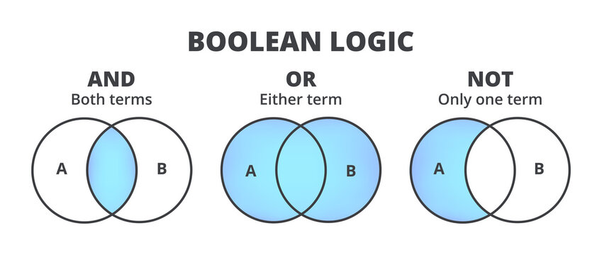

## `not`: the negation operator

- We can negate a condition using the `not` operator
- The `not` operator returns `True` if the condition is `False` and vice versa
  - Yes, it’s a bit confusing at first, but it’s intuitive once you see it in action
- For instance, imagine that you want to know whether someone can vote in the US
  - Here let’s assume the person is a national and we only care about age
  - The person can vote if they are at least 18 years old

```python
age  = 22

# Can this person legally vote in the US?
not (age < 18)
```

```
True
```

- The `not` operator can be separated by a space and parentheses are not necessary
- But parentheses can be helpful to organize your code logically

```python
not age < 18
```

```
True
```

## Condition A and B need to be satisfied: `&` operator

- We can test multiple conditions using the `&` operator
- The `&` operator returns `True` if both conditions are `True`
- For example, `5 > 3 & 5 < 10` returns `True`

```python
# We use the "&" symbol to separate "AND" conditions
age = 31

# Is this age between 20 and 30 (including these ages)?
( age >= 20 ) & (age <= 30)
```

```
False
```

## Condition A or B needs to be satisfied: `|` operator

- To test whether at least one condition is `True`, we use the `|` operator
- For example, `5 > 3 | 5 > 10` returns `True`

```python
# We use the "|" symbol to separate "OR" conditions.
age = 31

# Is this age higher than 20 or lower than 30?
( age >= 20 ) | (age <= 30)
```

```
True
```

```python
# Another example
student_status = "freshman"

# Is the student in the first two years of undergrad?
(student_status == "freshman") | (student_status == "sophomore")
```

```
True
```

## Try it out! 🚀

- Now, let’s test whether you can identify the correct expression
- Write code that checks the following conditions:
  - Whether age is strictly less than 20, or greater than 30
  - Not in the age range 25-27 Appendix 03

# Flow control: conditional statements 🐍

## Flow control: conditional statements

### If, elif, else

- Conditional statements are used to make decisions in programming
- The `if` statement is used to execute a block of code if a condition is `True`
- The `elif` statement is used to execute a block of code if the first condition is `False` and the second condition is `True`
- The `else` statement is used to execute a block of code if all other conditions are `False`
- We use this a lot in data cleaning or data analysis to filter out data!

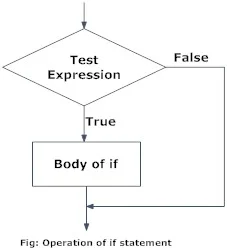

## If statements

- Test expression
  - We type “if” followed by a logical condition and the “:” symbol.
  - The “:” says: run the following command
- Body of expression
  - The “body” of the “if” statement needs to [indented with four spaces](https://www.python.org/dev/peps/pep-0008/#indentation)
  - You can indent text by pressing the “tab” button in your keyboard.
- If the condition is true, a message will appear.
- If the condition is false, then nothing happens
- The `if` statement syntax is as follows:

```python
if condition:
    Body
```

- Another example:

```python
# We start by defining a string
any_questions = "yes"

if any_questions == "yes":
    print("Need to give more explanations")
```

```
Need to give more explanations
```

## If/else statements

### When you have two possible outcomes

- The `else` statement is used to execute a block of code if the condition is `False`
- The `else` statement is always used in conjunction with the `if` statement
- The `else` statement syntax is as follows:

```python
if condition:
    Body
else:
    Body
```

- For example, let’s say you want to know whether someone can vote in the US
  - First, the person needs to be a national
  - Second, the person needs to be at least 18 years old

```python
age = 22
national = False

if national & (age >= 18):
    print("This person can vote in the US")
else:
    print("This person cannot vote in the US")
```

```
This person cannot vote in the US
```

## Another example

```python
# Here we want to change the colour of the histogram
# based on a conditional statement

is_graph_red = False
how_many_classes = np.array([7,1,2,3,3,3,4,5,6])

if is_graph_red:
    plt.hist(x = how_many_classes, color="red")
    plt.title("Count of students in each category")
    plt.xlabel("How many classes are you taking?")
    plt.show()
else:
    plt.hist(x = how_many_classes, color="purple")
    plt.title("Count of students in each category")
    plt.xlabel("How many classes are you taking?")
    plt.show()
```

- The histogram will be red if `is_graph_red` is `True`, and purple otherwise

[figure not shown]

## Try it out! 🚀

What happens if … ? Try the following:

- Rerun the above code but change the value of `is_graph_red`.
- What happens if you set a non-boolean value of `is_graph_red`?
- Don’t include `:`
- Don’t indent the body of the `if` Appendix 04

## If/elif/else statements

- The last conditional statement is the `elif` statement
- The `elif` statement is used to execute a block of code if the first condition is `False` and the second condition is `True`
- It is just like another `if` statement, but it is used when you have more than two possible outcomes
- The `elif` statement syntax is as follows:

```python
if condition:
    Body
elif condition:
    Body
else:
    Body
```

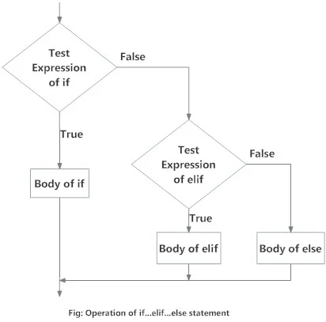

## Example

```python
years_in_program = 1

if years_in_program == 1:
    print("This student is a freshman")
elif years_in_program == 2:
    print("This student is a sophomore")
elif years_in_program == 3:
    print("This student is a junior")
else:
    print("This student is a senior")
```

```
This student is a freshman
```

# And that’s it for today! 🎉

# Questions? 🤔

## Try this at home! 🏠

- Practice writing conditional statements in Python
- Create a variable called “points” with a value between 0 and 100
- Write a flow with “if”, “elif” and “else” to assign the letter grade
- In the body, store the output in a new variable called “letter_grade”
- Print the letter grade at the end

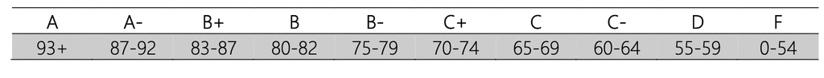

**Important**

Check that it works by trying different values of “points”!

# Thank you very much and see you next time! 🙏

## Appendix 01

```python
colors = ["red","green","yellow","orange"]

"red" in colors
```

```
True
```

Back to the main text

## Appendix 02

```python
x = -1

x**2 + 2*x + 1 == 0
```

```
True
```

Back to the main text

## Appendix 03

- Whether age (`age = 31`) is strictly less than 20, or greater than 30
- Not in the age range 25-27

```python
age = 31

(age < 20) | (age > 30)
```

```
True
```

```python
(age < 25) | (age > 27)
```

```
True
```

The second answer uses `|` because `&` evaluates both statements at the same time, and [one cannot be less than 25 and greater than 27 at the same time](https://en.wikipedia.org/wiki/Empty_set). Therefore, it must be `|`.

Back to the main text

## Appendix 04

What happens if `is_graph_red` is set to `True`?

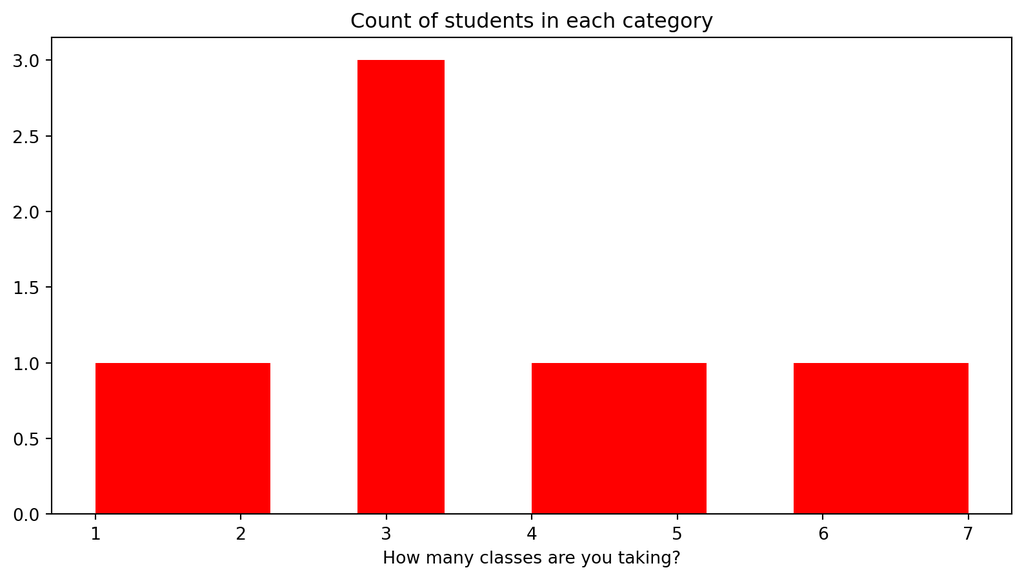

```python
is_graph_red = True
how_many_classes = np.array([7,1,2,3,3,3,4,5,6])

if is_graph_red:
    plt.hist(x = how_many_classes, color="red")
    plt.title("Count of students in each category")
    plt.xlabel("How many classes are you taking?")
    plt.show()
else:
    plt.hist(x = how_many_classes, color="purple")
    plt.title("Count of students in each category")
    plt.xlabel("How many classes are you taking?")
    plt.show()
```

Back to the main text

## Appendix 04 - Continued

What happens if you set a non-boolean value of `is_graph_red`?

[It is considered `True` if it is not zero](https://docs.python.org/3/library/stdtypes.html#truth-value-testing)

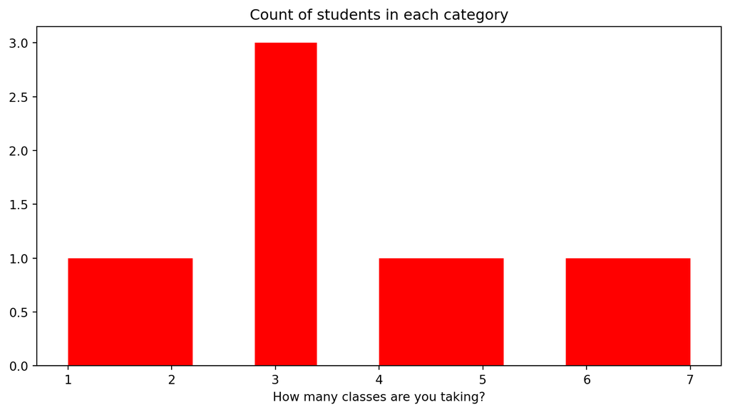

```python
is_graph_red = 39
how_many_classes = np.array([7,1,2,3,3,3,4,5,6])

if is_graph_red:
    plt.hist(x = how_many_classes, color="red")
    plt.title("Count of students in each category")
    plt.xlabel("How many classes are you taking?")
    plt.show()
else:
    plt.hist(x = how_many_classes, color="purple")
    plt.title("Count of students in each category")
    plt.xlabel("How many classes are you taking?")
    plt.show()
```

Back to the main text

## Appendix 04 - Continued

What happens if you don’t include `:`?

[You will get a syntax error](https://docs.python.org/3/reference/compound_stmts.html#if)

```python
is_graph_red = True
how_many_classes = np.array([7,1,2,3,3,3,4,5,6])

if is_graph_red
    plt.hist(x = how_many_classes, color="red")
    plt.title("Count of students in each category")
    plt.xlabel("How many classes are you taking?")
    plt.show()
else:
    plt.hist(x = how_many_classes, color="purple")
    plt.title("Count of students in each category")
    plt.xlabel("How many classes are you taking?")
    plt.show()
```

Back to the main text

## Appendix 04 - Continued

What happens if you don’t indent the body of the `if`?

[You will get another syntax error](https://docs.python.org/3/reference/compound_stmts.html#if)

```python
is_graph_red = True
how_many_classes = np.array([7,1,2,3,3,3,4,5,6])

if is_graph_red:
plt.hist(x = how_many_classes, color="red")
plt.title("Count of students in each category")
plt.xlabel("How many classes are you taking?")
plt.show()
else:
plt.hist(x = how_many_classes, color="purple")
plt.title("Count of students in each category")
plt.xlabel("How many classes are you taking?")
plt.show()
```

Back to the main text

[Conditional Statements](https://raw.githack.com/danilofreire/qtm151/main/lectures/lecture-05/05-boolean-if-else.html)